# CPI For Electricity Forecasting

## Data Gathering

```python
import pandas as pd
import numpy as np
import matplotlib.pyplot as plt
from sklearn.model_selection import TimeSeriesSplit
from statsmodels.tsa.seasonal import seasonal_decompose
from statsmodels.tsa.api import ExponentialSmoothing, SimpleExpSmoothing, Holt
import statsmodels.api as sm
from statsmodels.tsa import stattools
%matplotlib inline
```

```python
df=pd.read_csv("CPI_Electricity.csv",index_col="DATE",parse_dates=True)
df.head()
```

| DATE | CUUR0000SEHF01 |
| --- | --- |
| 1913-12-01 | 45.500 |
| 1914-01-01 | . |
| 1914-02-01 | . |
| 1914-03-01 | . |
| 1914-04-01 | . |

## Data Assessing and Cleaning

```python
df.head()
```

| DATE | CUUR0000SEHF01 |
| --- | --- |
| 1913-12-01 | 45.500 |
| 1914-01-01 | . |
| 1914-02-01 | . |
| 1914-03-01 | . |
| 1914-04-01 | . |

```python
df.info()
```

```
<class 'pandas.core.frame.DataFrame'>
DatetimeIndex: 1273 entries, 1913-12-01 to 2019-12-01
Data columns (total 1 columns):
CUUR0000SEHF01    1273 non-null object
dtypes: object(1)
memory usage: 19.9+ KB
```

```python
df.describe()
```

|  | CUUR0000SEHF01 |
| --- | --- |
| count | 1273 |
| unique | 562 |
| top | . |
| freq | 291 |

```python
df_clean=df.copy()
```

- Ambigious column name, rename the column with "CPI_electricity".

```python
df_clean.rename(columns={"CUUR0000SEHF01":"CPI_electricity"},inplace=True)
```

- Using "." to represent null values, convert dots into NaN.

```python
df_clean.replace(".",np.nan,inplace=True)
```

- Wrong data type of column "CPI_electricity", convert its type into float.

```python
df_clean["CPI_electricity"]=df_clean["CPI_electricity"].astype(float)
```

- Missing values in the dataset. Fill the missing values by forward filling method.

```python
df_clean.isnull().sum()
```

```
CPI_electricity    291
dtype: int64
```

```python
df_clean.fillna(method="ffill",inplace=True)
```

```python
df_clean.info()
```

```
<class 'pandas.core.frame.DataFrame'>
DatetimeIndex: 1273 entries, 1913-12-01 to 2019-12-01
Data columns (total 1 columns):
CPI_electricity    1273 non-null float64
dtypes: float64(1)
memory usage: 19.9 KB
```

```python
df_clean.index=pd.to_datetime(df_clean.index)
```

## Time series plot of CPI for electricity

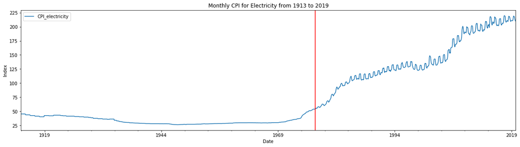

```python
df_clean.plot(figsize=(20,5),title="Monthly CPI for Electricity from 1913 to 2019")
plt.ylabel("Index");
plt.xlabel("Date");
plt.axvline(x="1977-01-01",color="red");
```

There was an upward and approximately linear trend and an obvious seasonal pattern after 1977, I decided to zoom in and used the data with a time range started from 1977-01-01.

```python
df_sub=df_clean.query("DATE>='1977-01-01'")
```

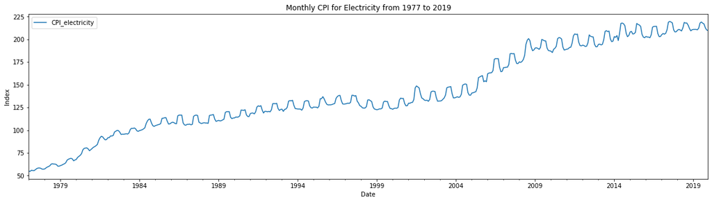

```python
df_sub.plot(figsize=(20,5),title="Monthly CPI for Electricity from 1977 to 2019")
plt.ylabel("Index");
plt.xlabel("Date");
```

## Seasonal Decomposition

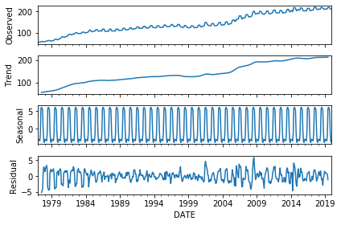

```python
nresult=seasonal_decompose(df_sub,model="None",freq=12)
nresult.plot();
plt.show();
```

We can see the residuals are more volatile in the early and later years, a roughly increasing error in recent years as compared with years between 1985 and 2001. There's also an upward approximately linear trend and a constant seasonal component as well.

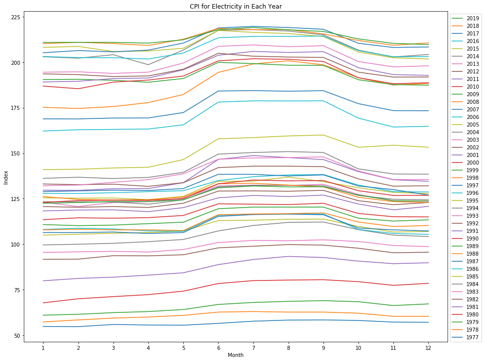

```python
# Split the dataset by year and check the seasonal pattern in each year.
year_list=df_sub.index.year.unique()
fig,ax = plt.subplots(figsize=(15,12))
for year in year_list:
    data=df_sub[df_sub.index.year==year]
    ax.plot(data.index.month,data["CPI_electricity"],label=year);
handles,labels=ax.get_legend_handles_labels()
ax.legend(reversed(handles),reversed(labels),bbox_to_anchor=(1,1),ncol=1);
loc=df_sub.index.month.unique().sort_values()
plt.xticks(loc,loc);
plt.xlabel("Month");
plt.ylabel("Index");
plt.title("CPI for Electricity in Each Year");
```

We can see there was always a peak in months June to September. In my guess, it's summertime between June and September, so the higher electricity consumption might because of the more usage of airconditioner. And the CPI for electricity is also a slightly higher in November and December, I guess this is because of the more heating needs during winter time.

### 1. Exponantial Smoothing Model

I'm going to use the Holt-Winter's Seasonal Smoothing Model based on the above analysis. One model doesn't have damping factor, the second one has damping factor.

```python
#Create training and testing vars
X=df_sub.index
y=df_sub["CPI_electricity"]
tscv=TimeSeriesSplit()
TimeSeriesSplit(max_train_size=None,n_splits=2)
for train_index,test_index in tscv.split(X):
    X_train,X_test=X[train_index],X[test_index]
    y_train,y_test=y[train_index],y[test_index]
```

```python
# Create training and testing subsets.
train=df_sub.iloc[train_index]
test=df_sub.iloc[test_index]
```

```python
model1=ExponentialSmoothing(train,trend="add",seasonal="add",seasonal_periods=12)
model2=ExponentialSmoothing(train,trend="add",seasonal="add",seasonal_periods=12,damped=True)

fit1=model1.fit()
pred1=fit1.forecast(test.shape[0])
fit2=model2.fit()
pred2=fit2.forecast(test.shape[0])

sse1 = np.sqrt(np.mean(np.square(test.values - pred1.values)))
sse2 = np.sqrt(np.mean(np.square(test.values - pred2.values)))
```

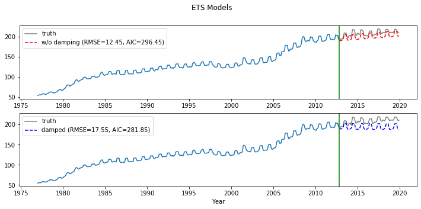

```python
fig,ax=plt.subplots(2,figsize=(12,5));
ax[0].plot(train.index, train.values);
ax[1].plot(train.index, train.values);
ax[0].plot(test.index, test.values, label='truth',color="gray");
ax[1].plot(test.index, test.values, label='truth',color="gray");
ax[0].plot(test.index, pred1, linestyle='--', color='Red', label="w/o damping (RMSE={:0.2f}, AIC={:0.2f})".format(sse1, fit1.aic));
ax[1].plot(test.index, pred2, linestyle='--', color='Blue', label="damped (RMSE={:0.2f}, AIC={:0.2f})".format(sse2, fit2.aic));
ax[0].legend();
ax[1].legend();
ax[0].axvline(x=X_test[0],color="green");
ax[1].axvline(x=X_test[0],color="green");
plt.suptitle("ETS Models");
plt.xlabel("Year");
```

*Exponential smoothing without damping result*

```python
print(fit1.summary())
```

```
                       ExponentialSmoothing Model Results
================================================================================
Dep. Variable:                    endog   No. Observations:                  430
Model:             ExponentialSmoothing   SSE                            795.346
Optimized:                         True   AIC                            296.447
Trend:                         Additive   BIC                            361.467
Seasonal:                      Additive   AICC                           298.111
Seasonal Periods:                    12   Date:                 Fri, 07 Feb 2020
Box-Cox:                          False   Time:                         02:37:52
Box-Cox Coeff.:                    None
=================================================================================
                          coeff                 code              optimized
---------------------------------------------------------------------------------
smoothing_level               0.5789474                alpha                 True
smoothing_slope               0.0443870                 beta                 True
smoothing_seasonal            0.4210526                gamma                 True
initial_level                 123.38070                  l.0                 True
initial_slope                 0.2940022                  b.0                 True
initial_seasons.0            -68.648375                  s.0                 True
initial_seasons.1            -68.034626                  s.1                 True
initial_seasons.2            -66.433864                  s.2                 True
initial_seasons.3            -65.836105                  s.3                 True
initial_seasons.4            -65.204600                  s.4                 True
initial_seasons.5            -64.124701                  s.5                 True
initial_seasons.6            -64.120047                  s.6                 True
initial_seasons.7            -64.931252                  s.7                 True
initial_seasons.8            -66.074223                  s.8                 True
initial_seasons.9            -67.494204                  s.9                 True
initial_seasons.10           -69.125084                 s.10                 True
initial_seasons.11           -69.140564                 s.11                 True
---------------------------------------------------------------------------------
```

*Exponential smoothing with damping result*

```python
print(fit2.summary())
```

```
                       ExponentialSmoothing Model Results
================================================================================
Dep. Variable:                    endog   No. Observations:                  430
Model:             ExponentialSmoothing   SSE                            765.226
Optimized:                         True   AIC                            281.846
Trend:                         Additive   BIC                            350.931
Seasonal:                      Additive   AICC                           283.700
Seasonal Periods:                    12   Date:                 Fri, 07 Feb 2020
Box-Cox:                          False   Time:                         02:37:52
Box-Cox Coeff.:                    None
=================================================================================
                          coeff                 code              optimized
---------------------------------------------------------------------------------
smoothing_level               0.6183826                alpha                 True
smoothing_slope               0.1468025                 beta                 True
smoothing_seasonal            0.3816169                gamma                 True
initial_level                 123.42362                  l.0                 True
initial_slope                 0.2670627                  b.0                 True
damping_slope                 0.9532172                  phi                 True
initial_seasons.0            -68.719603                  s.0                 True
initial_seasons.1            -67.979427                  s.1                 True
initial_seasons.2            -66.303207                  s.2                 True
initial_seasons.3            -65.520303                  s.3                 True
initial_seasons.4            -64.726772                  s.4                 True
initial_seasons.5            -63.607138                  s.5                 True
initial_seasons.6            -63.816156                  s.6                 True
initial_seasons.7            -64.887674                  s.7                 True
initial_seasons.8            -66.265482                  s.8                 True
initial_seasons.9            -67.904757                  s.9                 True
initial_seasons.10           -69.688349                 s.10                 True
initial_seasons.11           -69.705739                 s.11                 True
---------------------------------------------------------------------------------
```

### 2. Seasonal ARIMA Model

As we discovered a constant seasonal pattern above, I need to make the time series stationary.

```python
# Define a function for checking the stationarity of the series.
# These codes can be found at https://www.seanabu.com/2016/03/22/time-series-seasonal-ARIMA-model-in-python/
from statsmodels.tsa.stattools import adfuller
def test_stationarity(timeseries):

    #Determing rolling statistics
    rolmean = timeseries.rolling(window=12).mean()
    rolstd = timeseries.rolling(window=12).std()

    #Plot rolling statistics:
    fig = plt.figure(figsize=(12, 5))
    orig = plt.plot(timeseries, color='blue',label='Original')
    mean = plt.plot(rolmean, color='red', label='Rolling Mean')
    std = plt.plot(rolstd, color='black', label = 'Rolling Std')
    plt.legend(loc='best')
    plt.title('Rolling Mean & Standard Deviation')
    plt.xlabel("Year");
    plt.ylabel("Index");
    plt.show()

    #Perform Dickey-Fuller test:
    print('Results of Dickey-Fuller Test:')
    dftest = adfuller(timeseries, autolag='AIC')
    dfoutput = pd.Series(dftest[0:4], index=['Test Statistic','p-value','#Lags Used','Number of Observations Used'])
    for key,value in dftest[4].items():
        dfoutput['Critical Value (%s)'%key] = value
    print(dfoutput)
```

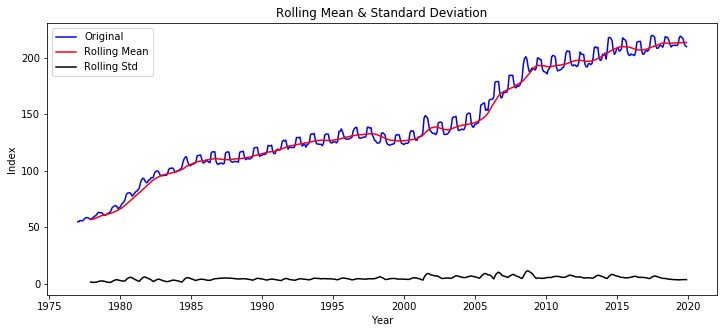

```
Results of Dickey-Fuller Test:
Test Statistic                  -1.099125
p-value                          0.715421
#Lags Used                      18.000000
Number of Observations Used    497.000000
Critical Value (1%)             -3.443576
Critical Value (5%)             -2.867373
Critical Value (10%)            -2.569877
dtype: float64
```

```python
test_stationarity(df_sub["CPI_electricity"])
```

The high p-value also comfirm that the time series is not stationary. Let's take a log of the time series.

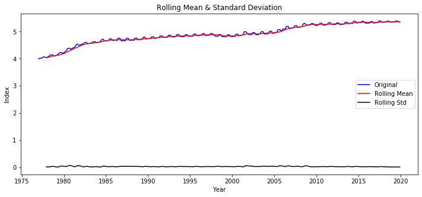

```
Results of Dickey-Fuller Test:
Test Statistic                  -2.454167
p-value                          0.127028
#Lags Used                      18.000000
Number of Observations Used    497.000000
Critical Value (1%)             -3.443576
Critical Value (5%)             -2.867373
Critical Value (10%)            -2.569877
dtype: float64
```

```python
df_sub["log"]=np.log(df_sub["CPI_electricity"])
test_stationarity(df_sub["log"].dropna(inplace=False))
```

The series is still not stationary enough. Let's take a first difference.

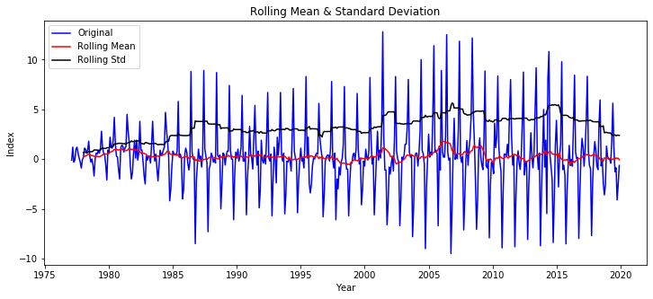

```
Results of Dickey-Fuller Test:
Test Statistic                  -4.983344
p-value                          0.000024
#Lags Used                      17.000000
Number of Observations Used    497.000000
Critical Value (1%)             -3.443576
Critical Value (5%)             -2.867373
Critical Value (10%)            -2.569877
dtype: float64
```

```python
df_sub["first_difference"]=df_sub["CPI_electricity"]-df_sub["CPI_electricity"].shift(1)
test_stationarity(df_sub["first_difference"].dropna(inplace=False))
```

This helped to improve the stationarity of the data, but it is not there yet. Let's try seasonal difference to remove the seasonality of the data and see how that impacts the stationarity of the data.

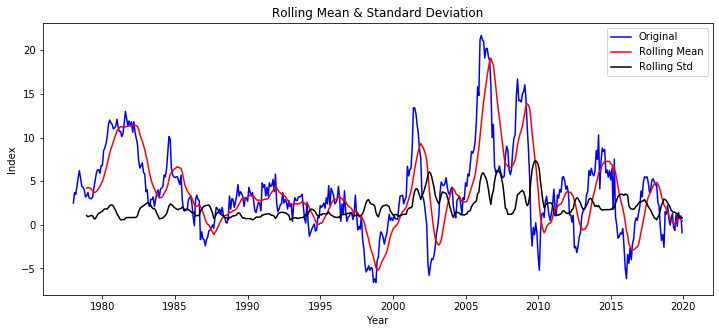

```
Results of Dickey-Fuller Test:
Test Statistic                  -3.137149
p-value                          0.023923
#Lags Used                      12.000000
Number of Observations Used    491.000000
Critical Value (1%)             -3.443739
Critical Value (5%)             -2.867444
Critical Value (10%)            -2.569915
dtype: float64
```

```python
df_sub["seasonal_difference"]=df_sub["CPI_electricity"]-df_sub["CPI_electricity"].shift(12)
test_stationarity(df_sub["seasonal_difference"].dropna(inplace=False))
```

Compared to the original data, this is an improvement, but we are not there yet. Next, let's take a first difference of the seasonal difference.

```python
df_sub["seasonal_first_difference"]=df_sub["first_difference"]-df_sub["first_difference"].shift(12)
```

Taking a first difference of seasonal difference.

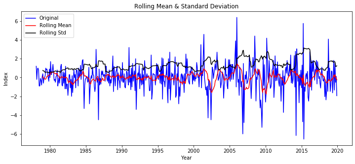

```
Results of Dickey-Fuller Test:
Test Statistic                -9.758365e+00
p-value                        7.680559e-17
#Lags Used                     1.100000e+01
Number of Observations Used    4.910000e+02
Critical Value (1%)           -3.443739e+00
Critical Value (5%)           -2.867444e+00
Critical Value (10%)          -2.569915e+00
dtype: float64
```

```python
test_stationarity(df_sub["seasonal_first_difference"].dropna(inplace=False))
```

The p-value Dickey-Fuller test of seasonal_first_difference series is very close to zero. This series is stationary now.

- Plot the ACF and PACF and find the optimal parameters for these models.

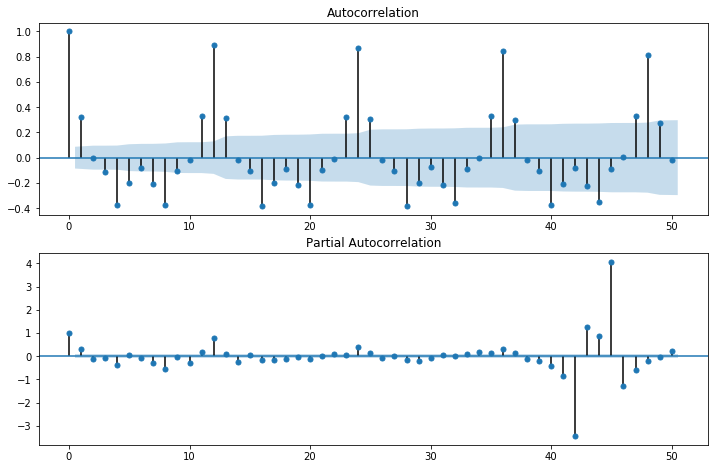

```python
# first_difference
fig=plt.figure(figsize=(12,12))
ax1=fig.add_subplot(311)
fig=sm.graphics.tsa.plot_acf(df_sub["first_difference"].dropna(inplace=False),lags=50,ax=ax1)
ax2=fig.add_subplot(312)
fig=sm.graphics.tsa.plot_pacf(df_sub["first_difference"].dropna(inplace=False),lags=50,ax=ax2)
```

There are too many seasonal and strong correlation show in the acf plot and , we can not accept the first_difference.

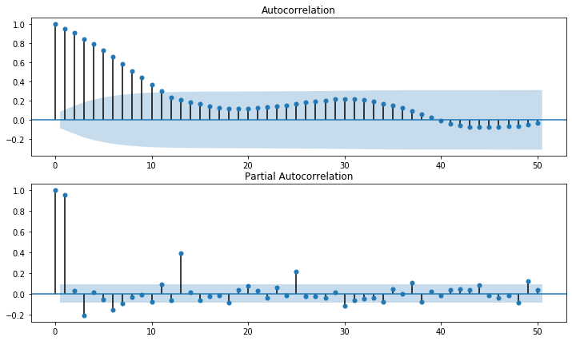

```python
# seasonal_difference
fig=plt.figure(figsize=(12,7))
ax1=fig.add_subplot(211)
fig=sm.graphics.tsa.plot_acf(df_sub["seasonal_difference"].dropna(inplace=False),lags=50,ax=ax1)
ax2=fig.add_subplot(212)
fig=sm.graphics.tsa.plot_pacf(df_sub["seasonal_difference"].dropna(inplace=False),lags=50,ax=ax2)
```

There are strong correlation show in the acf and and a seasonal pattern in pacf as well. We can't accept it.

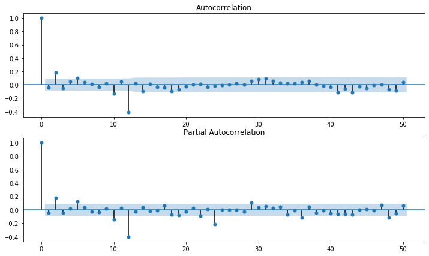

```python
# seasonal_first_difference
fig=plt.figure(figsize=(12,7))
ax1=fig.add_subplot(211)
fig=sm.graphics.tsa.plot_acf(df_sub["seasonal_first_difference"].dropna(inplace=False),lags=50,ax=ax1)
ax2=fig.add_subplot(212)
fig=sm.graphics.tsa.plot_pacf(df_sub["seasonal_first_difference"].dropna(inplace=False),lags=50,ax=ax2)
```

```python
# ARIMA(1,1,0)x(0,1,1)12.
mod=sm.tsa.statespace.SARIMAX(df_sub["CPI_electricity"], trend='n', order=(1,1,0), seasonal_order=(0,1,1,12))
results = mod.fit()
```

```python
df_sub['forecast'] = results.predict(start = X_test[0], end= X_test[-1], dynamic= True)
```

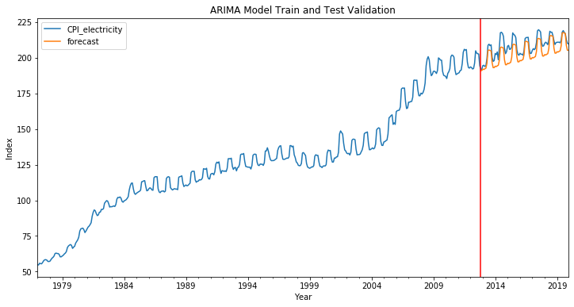

```python
df_sub[['CPI_electricity', 'forecast']].plot(figsize=(12, 6))
plt.axvline(x=X_test[0],color="Red");
plt.title("ARIMA Model Train and Test Validation");
plt.xlabel("Year");
plt.ylabel("Index");
```

```python
print(results.summary())
```

```
                                 Statespace Model Results
==========================================================================================
Dep. Variable:                    CPI_electricity   No. Observations:                  516
Model:             SARIMAX(1, 1, 0)x(0, 1, 1, 12)   Log Likelihood                -839.593
Date:                            Fri, 07 Feb 2020   AIC                           1685.186
Time:                                    02:37:57   BIC                           1697.847
Sample:                                01-01-1977   HQIC                          1690.153
                                     - 12-01-2019
Covariance Type:                              opg
==============================================================================
                 coef    std err          z      P>|z|      [0.025      0.975]
------------------------------------------------------------------------------
ar.L1         -0.0196      0.037     -0.529      0.597      -0.092       0.053
ma.S.L12      -0.6187      0.027    -22.739      0.000      -0.672      -0.565
sigma2         1.6306      0.057     28.598      0.000       1.519       1.742
===================================================================================
Ljung-Box (Q):                       37.81   Jarque-Bera (JB):               602.02
Prob(Q):                              0.57   Prob(JB):                         0.00
Heteroskedasticity (H):               2.36   Skew:                             0.41
Prob(H) (two-sided):                  0.00   Kurtosis:                         8.30
===================================================================================

Warnings:
[1] Covariance matrix calculated using the outer product of gradients (complex-step).
```

## Compare the models

```python
# Calculate the residuals of exponential smoothing model without and with damping, and the residual of ARIMA model.
residual_ets1=pred1-y_test
residual_ets2=pred2-y_test
residual_ARIMA=df_sub["forecast"]-y_test
```

- *Residual plots*

*ACF and PACF plots of exponential smoothing model without dampening.*

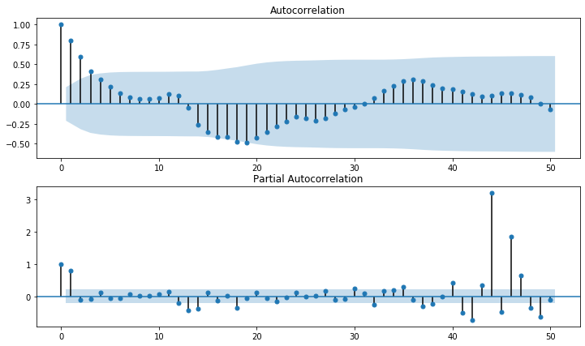

```python
#ACF and PACF plots of exponential smoothing model without damping.
fig=plt.figure(figsize=(12,7))
ax1=fig.add_subplot(211)
fig=sm.graphics.tsa.plot_acf(residual_ets1.dropna(inplace=False),lags=50,ax=ax1,alpha=0.05)
ax2=fig.add_subplot(212)
fig=sm.graphics.tsa.plot_pacf(residual_ets1.dropna(inplace=False),lags=50,ax=ax2,alpha=0.05)
```

*ACF and PACF plots of exponential smoothing model with dampening.*

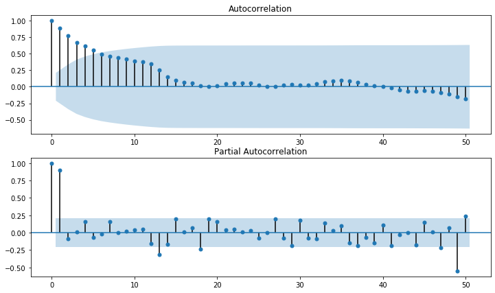

```python
#ACF and PACF plots of exponential smoothing model with damping.
fig=plt.figure(figsize=(12,7))
ax1=fig.add_subplot(211)
fig=sm.graphics.tsa.plot_acf(residual_ets2.dropna(inplace=False),lags=50,ax=ax1,alpha=0.05)
ax2=fig.add_subplot(212)
fig=sm.graphics.tsa.plot_pacf(residual_ets2.dropna(inplace=False),lags=50,ax=ax2,alpha=0.05)
```

*ACF and PACF plots of ARIMA model.*

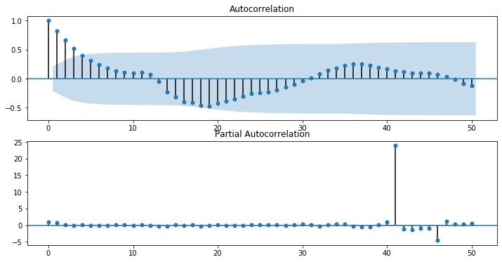

```python
#ACF and PACF plots of ARIMA model.
fig=plt.figure(figsize=(12,6))
ax1=fig.add_subplot(211)
fig=sm.graphics.tsa.plot_acf(residual_ARIMA.dropna(inplace=False),lags=50,ax=ax1,alpha=0.05)
ax2=fig.add_subplot(212)
fig=sm.graphics.tsa.plot_pacf(residual_ARIMA.dropna(inplace=False),lags=50,ax=ax2,alpha=0.05)
```

From the above plots, we can see the ETS model with damping has fewer strong autocorrelations in ACF and partial autocorrelation in PACF. ETS model is better.

- *Information Criteria*  
  From the above result summary of each model, we've already known the AIC and BIC.

```python
ic=pd.DataFrame(data={"AIC":[296.447,281.846,1685.186],"BIC":[361.467,350.931,1697.847]},index=[["ETS without damping","ETS with damping","ARIMA"]])
print(ic)
```

```
                          AIC       BIC
ETS without damping   296.447   361.467
ETS with damping      281.846   350.931
ARIMA                1685.186  1697.847
```

ARIMA model has a much higher AIC and BIC than ETS model without damping. Therefore, we are going to choose between ETS without damping and ETS with damping. However, the accuary level of them are similar. Let's move to the measures of erroe analysis.

- *Measures of Error*

```python
#Calculate the MAE, MSE, MAPE, MPE, ME, RMSE for the three model.
MAE=[]
MSE=[]
MAPE=[]
MPE=[]
ME=[]
RMSE=[]

for i,p in zip(range(5),[pred1,pred2,df_sub["forecast"]]):
    mae_sum=(y_test-p).sum()
    mae=mae_sum/len(y_test)
    mse_sum=((y_test-p)**2).sum()
    mse=mse_sum/len(y_test)
    mape_sum=((abs(y_test-p))/y_test).sum()
    mape=mape_sum/len(y_test)
    mpe_sum=((y_test-p)/y_test).sum()
    mpe=mpe_sum/len(y_test)
    me_sum=(y_test-p).sum()
    me=me_sum/len(y_test)
    rsme=np.sqrt(((y_test-p)**2).sum()/len(y_test))
    MAE.append(mae)
    MSE.append(mse)
    MAPE.append(mape)
    MPE.append(mpe)
    ME.append(me)
    RMSE.append(rsme)
```

```python
error=pd.DataFrame(data={"MAE":MAE,"MSE":MSE,"MAPE":MAPE,"MPE":MPE,"ME":ME,"RMSE":RMSE},index=[["ETS without damping","ETS with damping","ARIMA"]])
print(error)
```

```
                           MAE         MSE      MAPE       MPE         ME  \
ETS without damping   7.714177   68.223120  0.036893  0.036893   7.714177
ETS with damping     14.886434  249.112637  0.070992  0.070992  14.886434
ARIMA                 5.369259   36.375087  0.025718  0.025706   5.369259

                          RMSE
ETS without damping   8.259729
ETS with damping     15.783302
ARIMA                 6.031176
```

# Forecasting

```python
# We add the test data back to forecast the CPI for electricity in the next year 2020.
# multi-step out-of-sample forecast
model=ExponentialSmoothing(df_sub["CPI_electricity"],trend="add",seasonal="add",seasonal_periods=12)
fit=model.fit()
forecast=fit.forecast(steps=12)
```

```python
print(forecast)
```

```
2020-01-01    210.306609
2020-02-01    210.806751
2020-03-01    210.342883
2020-04-01    209.393323
2020-05-01    211.793384
2020-06-01    218.798564
2020-07-01    220.466712
2020-08-01    220.491329
2020-09-01    219.989020
2020-10-01    215.179488
2020-11-01    211.671261
2020-12-01    210.862968
Freq: MS, dtype: float64
```

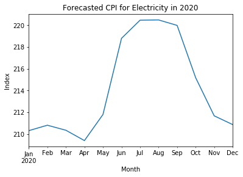

```python
forecast.plot();
plt.title("Forecasted CPI for Electricity in 2020");
plt.ylabel("Index");
plt.xlabel("Month");
```